# R & RStudio Basics

Workshop Pt. 1: from zero to your first dataset

Vrinda Malhotra

2026-11-15

## Today

| Segment | Topic | Time |
| --- | --- | --- |
| Intro | What R and RStudio are, and why use them | 10 min |
| Warm-up | Variables and functions: a knowledge check | 5 min |
| Module 1 | Setup and RStudio | 20 min |
| Module 2 | R fundamentals | 40 min |
| Module 3 | Importing and inspecting data | 25 min |
| Put it together | Explore the penguins | 15 min |
| Wrap-up | Readiness check, questions | 5 min |

All of today’s code in one file: pt1-code.R · Pt. 2 covers wrangling, figures, statistics and reproducible reports.

# Intro: what are R and RStudio?

No programming experience needed

## What is R?

R is a **language for working with data**. You write short instructions; R carries them out.

```r
mean(c(12, 15, 9))   # "give me the average of 12, 15 and 9"
```

- In a spreadsheet you **click** to get a result, and the clicks are gone.
- In R you **write down** each step. The steps are saved, so you can rerun, check or share them.
- That written list of steps is a **script**. Writing one is all the “programming” you will do today.

## R and RStudio are two different things

R The **engine**. It does the calculations. You rarely open it directly.

RStudio The **dashboard**. A program for writing, running and organizing R code, with panes for your data, plots and help.

You install both, but you only ever open **RStudio**. It runs R for you behind the scenes.

## You already do this in a spreadsheet

| What you want | Spreadsheet | R |
| --- | --- | --- |
| Average a column | `=AVERAGE(B2:B345)` | `mean(body_mass_g)` |
| Keep some rows | Filter menu, tick boxes | `filter(species == "Gentoo")` |
| Sort | Sort button | `arrange(body_mass_g)` |
| Make a chart | Chart wizard | `ggplot(...)` |
| Redo it all on new data | Repeat every click | **Rerun the script** |

If you’ve written a spreadsheet formula, you’ve already written code.

## Why R?

- **Reproducible.** Your analysis is a script. Rerun it and get the same answer, or point it at new data.
- **Free and open.** No licence, runs on every OS, used across every research field.
- **Huge ecosystem.** 20,000+ packages on CRAN for statistics, figures, text, maps, surveys, genomics.
- **A record of what you did.** Reviewers, collaborators and future-you can see every step.

## What to expect today

- **It will feel slower than clicking at first.** The payoff comes the second time you run an analysis.
- **Errors are normal**, even for experts. Each one tells you what to fix, and we’ll practise reading them.
- **Type along** rather than copy-paste. Your fingers learn the syntax.
- **Ask anytime.** If you’re stuck, someone else is too.

# Warm-up: variables and functions

Two ideas you already know, from math and from everyday life

## Quick check

In math class you saw:

$$y = 2x + 3$$

- What is **x**?
- If x = 4, what is **y**?
- What is the **rule** that turns x into y?

## Variables: a name that stands for a value

|  | Example | The name | The value |
| --- | --- | --- | --- |
| **Math** | x = 5, so x + 2 = 7 | `x` | 5 |
| **Everyday** | A contact in your phone called “Mom” | Mom | her phone number |
| **R** | `x <- 5`, then `x + 2` gives 7 | `x` | 5 |

- You use the **name**; R looks up the **value**.
- In R a variable is called an **object**, and `<-` means “store this value under this name”.
- Unlike in math, the value can be **replaced**: `x <- 10` puts a new number under the same name, like updating Mom’s number.

## Functions: input → rule → output

|  | Example | Input | Output |
| --- | --- | --- | --- |
| **Math** | f(x) = 2x + 3, so f(4) | 4 | 11 |
| **Everyday** | A coffee machine | beans, water, “large” | a large coffee |
| **R** | `round(3.14159, digits = 2)` | 3.14159 and 2 | 3.14 |

3.14159, 2inputs

→

round()function

→

3.14output

In R: **name of the function**, then inputs in round brackets. The inputs are called **arguments**.

## Knowledge check 3 min

1. In `height <- 172`, what is the name and what is the value?
2. In `sqrt(16)`, what is the function, the input, and the output?
3. After `price <- 4` and then `price <- price + 1`, what is `price`?
1. Name `height`, value 172
2. Function `sqrt` (square root), input 16, output 4
3. **5**. Read it as “take the old price, add 1, store it back as price”. In math, x = x + 1 is impossible; in R, `<-` means *store*, not *equals*.

# Module 1: Setup and RStudio

20 minutes

## Install R, then RStudio

1. **R** from [cran.r-project.org](https://cran.r-project.org/): the engine
2. **RStudio Desktop** from [posit.co](https://posit.co/download/rstudio-desktop/): the dashboard

Then open **RStudio** (not R).

## The four panes

**Source** Scripts you save. Your analysis lives here.

**Environment** Objects currently in memory.

**Console** Runs code immediately. Quick checks only.

**Files · Plots · Packages · Help** File browser, figures, installed packages, documentation.

Run a line from a script: **Ctrl+Enter** (Windows) · **Cmd+Enter** (Mac)

## Install the packages

**Packages** are free add-ons that give R extra tools, like apps on a phone. Install the ones we need by typing this into the **Console** and pressing Enter:

```r
install.packages(c("tidyverse", "palmerpenguins", "here",
                   "broom", "car", "emmeans", "janitor", "Hmisc",
                   "patchwork", "quarto", "renv"))
```

Text will scroll by for a few minutes. That’s normal. Red text isn’t always an error; look for the word **Error**.

## Your workspace

Everything you work with in an analysis lives in one of two places:

Files Saved on your computer, in a folder: your data, your scripts, your figures. **Permanent.** Still there tomorrow.

Memory The objects you create while working, listed in the **Environment** pane. **Temporary.** Gone when you close or restart R.

Keep all the files for one analysis in **one folder**. R then knows where to find them, and nothing gets lost on your Desktop or in Downloads.

## The working directory

R is always “standing in” one folder: the **working directory**. When you name a file, R looks for it there.

```r
getwd()                    # "get working directory": where is R standing?
```

```
#> "/Users/you/Documents"
```

```r
read_csv("penguins.csv")   # looks for /Users/you/Documents/penguins.csv
```

```
#> Error: 'penguins.csv' does not exist in current working directory
#> ('/Users/you/Documents').
```

→ Type `getwd()` in your Console. Where is R standing?

## Two kinds of file path

| Path | Example | Like… | Works on |
| --- | --- | --- | --- |
| **Absolute**: the full address | `"/Users/you/Desktop/project/data/penguins.csv"` | A full street address | Only your computer |
| **Relative**: starts from the working directory | `"data/penguins.csv"` | “Second door on the left” | Any computer, if R is standing in the right folder |

Relative paths are portable, but only if R starts in the right folder. So how do we set it?

## Setting the working directory

Three ways, from least to most reproducible:

1. **In code:** `setwd("/Users/you/Desktop/project")`
2. **From the menu:** Session → Set Working Directory → Choose Directory…
3. **Open an RStudio Project:** the working directory is set to the project folder automatically ✓

Options 1 and 2 work today, on your computer. Option 3 works on anyone’s computer, every time.

## One RStudio Project per analysis

An **RStudio Project** is one folder for one analysis. Opening it sets the working directory to that folder, so relative paths just work.

File → New Project → New Directory

```
penguin-analysis/
├── penguin-analysis.Rproj   # double-click to open the project
├── data/
│   ├── raw/          # never edited
│   └── processed/    # written by your scripts
├── R/                # analysis scripts
├── figures/
└── report.qmd
```

→ Switch to RStudio: create this project together, then run `getwd()` again

## Why not just use `setwd()`?

Your script, run on a collaborator’s laptop:

```r
setwd("C:/Users/me/Desktop/project")
```

```
#> Error in setwd("C:/Users/me/Desktop/project"): cannot change working directory
```

- That folder doesn’t exist on their computer.
- It breaks for **you** too if you rename the folder, move it, or get a new laptop.
- With a Project, there’s nothing to set: whoever opens the `.Rproj` starts in the right place.

## `here()`: paths from the project folder

`here()` builds a path starting from the project folder, wherever your script sits inside it.

```r
library(here)
here("data", "raw", "penguins_raw.csv")
```

```
#> "/Users/you/penguin-analysis/data/raw/penguins_raw.csv"
```

Do

```r
# open penguin-analysis.Rproj, then:
read_csv(here("data", "raw", "file.csv"))
```

Don’t

```r
setwd("C:/Users/me/Desktop/project")
read_csv("file.csv")
```

Why `here()` and not just `"data/raw/file.csv"`? Quarto reports and scripts in subfolders can start in a different folder. `here()` always starts at the project.

# Module 2: R fundamentals

40 minutes

## Objects and assignment

Remember variables from the warm-up? In R they’re **objects**, created with `<-` (shortcut: **Alt + –**).

```r
mass_g <- 3750
species <- "Adelie"
mass_kg <- mass_g / 1000
mass_kg
```

```
[1] 3.75
```

→ Switch to RStudio: open a new script (File → New File → R Script)

## Vectors: R’s basic unit

A vector holds values of one type. Operations apply to **every element at once**.

```r
masses <- c(3750, 3800, 3250, NA, 3450)
masses / 1000
```

```
[1] 3.75 3.80 3.25   NA 3.45
```

```r
masses[2]               # the 2nd value: counting starts at 1
```

```
[1] 3800
```

```r
masses[c(1, 3)]         # the 1st and 3rd values
```

```
[1] 3750 3250
```

## Data types you’ll meet

| Type | Example | Research use |
| --- | --- | --- |
| numeric | `3.75` | Measurements, scores |
| integer | `12L` | Counts |
| character | `"Biscoe"` | Labels, IDs, free text |
| logical | `TRUE`, `FALSE` | Conditions, filters |
| factor | `factor(c("low", "high"))` | Groups, treatments |
| Date | `as.Date("2026-11-15")` | Collection dates |

Check any object with `class(x)`.

## Factors: categories with an order

```r
dose <- factor(c("high", "low", "medium", "low"))
levels(dose)            # alphabetical by default
```

```
[1] "high"   "low"    "medium"
```

```r
dose <- factor(dose, levels = c("low", "medium", "high"))
levels(dose)            # now in a meaningful order
```

```
[1] "low"    "medium" "high"
```

The **first level is the reference group** in statistical models, and sets the order in plots. Set it on purpose.

## Missing values: `NA`

R won’t silently drop data.

```r
mean(masses)
```

```
[1] NA
```

```r
mean(masses, na.rm = TRUE)
```

```
[1] 3562.5
```

```r
sum(is.na(masses))
```

```
[1] 1
```

Always report how many observations you dropped, and why.

## Conditions: yes-or-no questions

A **condition** asks a question. R answers `TRUE` or `FALSE`, once for every value.

|  | Example |
| --- | --- |
| **Everyday** | “Which days this week were warmer than 24 °C?” |
| **Spreadsheet** | Filter → Number filters → Greater than… |
| **R** | `temps > 24` |

```r
temps <- c(18, 25, 31, 22, 29)   # daily highs, °C
temps > 24
```

```
[1] FALSE  TRUE  TRUE FALSE  TRUE
```

## Asking questions in R

| Operator | Question | Example | Answer |
| --- | --- | --- | --- |
| `>` `<` | greater / less than? | `5 > 3` | `TRUE` |
| `>=` `<=` | at least / at most? | `5 <= 3` | `FALSE` |
| `==` | equal to? | `"Adelie" == "Gentoo"` | `FALSE` |
| `!=` | not equal to? | `"Adelie" != "Gentoo"` | `TRUE` |
| `&` | both true? | `temps > 20 & temps < 30` | per value |
| `\|` | either true? | `temps < 20 \| temps > 30` | per value |

Watch out: `==` **asks** “is it equal?”. `<-` **stores** a value. Mixing them up is the most common beginner slip.

## Using conditions

```r
temps[temps > 24]                # keep the values where the answer is TRUE
```

```
[1] 25 31 29
```

```r
sum(temps > 24)                  # TRUE counts as 1: how many warm days?
```

```
[1] 3
```

```r
mean(temps > 24)                 # share of days that were warm
```

```
[1] 0.6
```

A missing value gives a missing answer, so tell R what to do with it:

```r
masses > 3500
```

```
[1]  TRUE  TRUE FALSE    NA FALSE
```

```r
sum(masses > 3500, na.rm = TRUE)
```

```
[1] 2
```

## Functions and packages

From the warm-up: a function takes inputs (**arguments**) and returns an output.

```r
round(3.14159, digits = 2)
```

```
[1] 3.14
```

A package bundles functions.

```r
install.packages("palmerpenguins")   # once per computer
library(palmerpenguins)              # once per session
```

## Getting help

- `?mean`: help page; scroll to **Examples** at the bottom
- `??regression`: search every installed help page
- Read errors **from the end**: the last line names the problem
- Asking others? Make a minimal example with the `reprex` package

```r
?mean
```

## Where does your work live? 5 min

1. Save your script: **Ctrl+S** / **Cmd+S**.
2. Look at the Environment pane. Every object you made is listed.
3. Restart R: **Session → Restart R**. What happened to the Environment?
4. Rerun your whole script: **Ctrl+Shift+Enter** / **Cmd+Shift+Enter**.

Everything came back. **Your script is your backup, not what’s in memory.**

- Objects in memory are temporary; the steps in your script rebuild them.
- Protect the script: save often, and keep the project in a backed-up folder (OneDrive, Google Drive, Dropbox). Pt. 2 adds version control.

## Optional: start every session clean

When you quit, RStudio asks **“Save workspace image?”** That’s the **Memory** side of your workspace: the objects, not the steps that made them.

Many R users turn it off so nothing works only because of leftovers in memory:

Tools → Global Options → General

- **Restore .RData into workspace at startup:** unchecked
- **Save workspace to .RData on exit:** Never

Your choice. If you leave it on, restart R and rerun your script before you trust a result.

## Exercise: vectors 5 min

1. Create a vector of five bill lengths (mm), one of them `NA`.
2. Compute the mean, ignoring the missing value.
3. Count how many values are above 40 mm.

```r
bills <- c(39.1, 39.5, NA, 46.5, 50.0)
mean(bills, na.rm = TRUE)
```

```
[1] 43.775
```

```r
sum(bills > 40, na.rm = TRUE)
```

```
[1] 2
```

# Module 3: Importing and inspecting data

25 minutes

## Meet the penguins

Our practice data, from the `palmerpenguins` package:

- **344 penguins**, 3 species: Adelie, Chinstrap, Gentoo
- Collected on 3 islands near Palmer Station, Antarctica, 2007–2009
- One row per penguin: bill length and depth, flipper length, body mass, sex, island, year
- Two versions: `penguins` (cleaned) and `penguins_raw` (as recorded in the field, messy column names)

## Read a CSV

Inside your project, save the raw data, then read it back like a real file:

```r
library(tidyverse)
library(palmerpenguins)
library(here)

dir.create(here("data", "raw"), recursive = TRUE, showWarnings = FALSE)
write_csv(penguins_raw, here("data", "raw", "penguins_raw.csv"))

penguins_raw <- read_csv(here("data", "raw", "penguins_raw.csv"))
```

`read_csv()` reports the type it guessed for each column. **Read that message.** A number column read as text usually means a stray `"n/a"` or `"<0.1"`.

## First look: `glimpse()`

```r
glimpse(penguins, width = 70)
```

```
Rows: 344
Columns: 8
$ species           <fct> Adelie, Adelie, Adelie, Adelie, Adelie, Ad…
$ island            <fct> Torgersen, Torgersen, Torgersen, Torgersen…
$ bill_length_mm    <dbl> 39.1, 39.5, 40.3, NA, 36.7, 39.3, 38.9, 39…
$ bill_depth_mm     <dbl> 18.7, 17.4, 18.0, NA, 19.3, 20.6, 17.8, 19…
$ flipper_length_mm <int> 181, 186, 195, NA, 193, 190, 181, 195, 193…
$ body_mass_g       <int> 3750, 3800, 3250, NA, 3450, 3650, 3625, 46…
$ sex               <fct> male, female, female, NA, female, male, fe…
$ year              <int> 2007, 2007, 2007, 2007, 2007, 2007, 2007, …
```

## First look: `summary()` and `count()`

```r
summary(penguins$body_mass_g)
```

```
   Min. 1st Qu.  Median    Mean 3rd Qu.    Max.    NA's
   2700    3550    4050    4202    4750    6300       2
```

```r
count(penguins, island)
```

```
# A tibble: 3 × 2
  island        n
  <fct>     <int>
1 Biscoe      168
2 Dream       124
3 Torgersen    52
```

Also try `head(penguins)` and `View(penguins)`.

## Other formats

| Source | Function | Package |
| --- | --- | --- |
| CSV | `read_csv()` | readr |
| Tab-delimited / instrument output | `read_tsv()`, `read_delim()` | readr |
| Excel | `read_excel(path, sheet = 2)` | readxl |
| SPSS, Stata, SAS | `read_sav()`, `read_dta()`, `read_sas()` | haven |

Tell R which codes mean missing: `read_csv(path, na = c("", "NA", "n/a", "-999"))`

## Tidy data

Each **variable** is a column · each **observation** is a row · each **value** is a cell.

Wide: “week” is hidden in the column names

```
 id week1 week2
  1   5.1   5.6
  2   4.8   5.0
```

Tidy: one row per measurement

```
 id  week score
  1 week1   5.1
  1 week2   5.6
  2 week1   4.8
  2 week2   5.0
```

Pt. 2 shows how to reshape with `pivot_longer()`.

## Exercise: inspect the penguins 5 min

1. How many penguins have no recorded sex?
2. Which island has the most penguins?
3. What type is the `year` column?

```r
sum(is.na(penguins$sex))
count(penguins, island, sort = TRUE)
class(penguins$year)
```

1. **11** penguins
2. **Biscoe** (168 penguins)
3. **integer**: whole numbers

# Put it together: explore the penguins

15 minutes · run the code, then change it

## 1. Who lives where? 5 min

You know `count()` from Module 3. Count penguins by **island and species** together. Which species live on only one island?

```r
count(penguins, island, species)
```

```
# A tibble: 5 × 3
  island    species       n
  <fct>     <fct>     <int>
1 Biscoe    Adelie       44
2 Biscoe    Gentoo      124
3 Dream     Adelie       56
4 Dream     Chinstrap    68
5 Torgersen Adelie       52
```

Gentoo live only on Biscoe and Chinstrap only on Dream; Adelie live on all three islands.

## 2. Averages per group 5 min

Run this, then change it to give the mean **flipper length** per species.

```r
penguins |>
  group_by(species) |>
  summarise(mean_mass_g = mean(body_mass_g, na.rm = TRUE))
```

Read `|>` as “and then”. Pt. 2 explains each piece.

```r
penguins |>
  group_by(species) |>
  summarise(mean_flipper_mm =
    mean(flipper_length_mm, na.rm = TRUE))
```

```
# A tibble: 3 × 2
  species   mean_flipper_mm
  <fct>               <dbl>
1 Adelie               190.
2 Chinstrap            196.
3 Gentoo               217.
```

## 3. Your first plot 5 min

Run this, then put **bill length** on the x-axis. Do the species still separate?

```r
ggplot(penguins, aes(x = flipper_length_mm, y = body_mass_g, colour = species)) +
  geom_point()
```

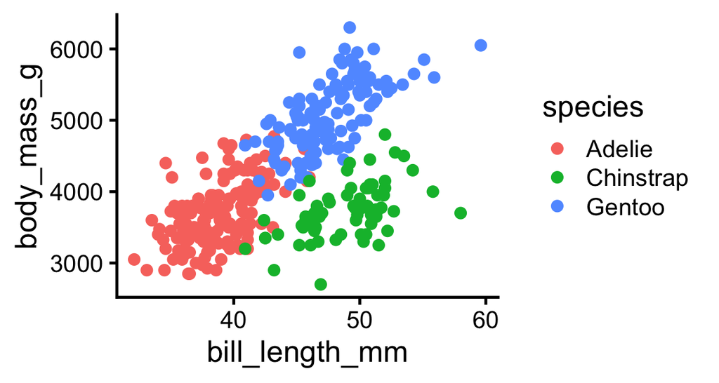

```r
ggplot(penguins,
       aes(x = bill_length_mm,
           y = body_mass_g,
           colour = species)) +
  geom_point()
```

## What you just did

- A few lines replaced a pivot table, a chart wizard, and notes on how you made them.
- Get new data next year? **Rerun the script.** Every number and figure updates.
- Pt. 2 teaches each piece so you can write these from scratch.

# Wrap-up

## Ready for Pt. 2?

- R and RStudio installed; every package installed without errors
- Your script is saved in the project and reruns cleanly after **Session → Restart R**
- An RStudio Project with `data/`, `R/` and `figures/`
- `data/raw/penguins_raw.csv` exists inside it
- `glimpse(penguins)` runs, and you can name each column’s type

Package won’t install? Show the instructor before you leave.

## Errors you’ll see this week

| Message | Fix |
| --- | --- |
| `could not find function "ggplot"` | `library(tidyverse)` |
| `there is no package called 'x'` | `install.packages("x")` |
| `object 'x' not found` | Check spelling and case; run the script from the top |
| `cannot open file ... No such file` | Open the `.Rproj`; build paths with `here()` |
| A `+` in the Console that won’t go away | Press **Esc**, fix the line |

## Next time and resources

**Pt. 2:** wrangling with dplyr · figures with ggplot2 · t-tests, ANOVA, regression · Quarto reports

- [R for Data Science (2e)](https://r4ds.hadley.nz/): free, the standard next step
- [Posit cheat sheets](https://posit.co/resources/cheatsheets/): one-page references
- [The Carpentries R lessons](https://datacarpentry.org/lessons/): workshop material by field
- [palmerpenguins](https://allisonhorst.github.io/palmerpenguins/): Horst, Hill & Gorman (2020)